# Exploring vital rate models

### –s3: logit(S1) = b0 + b1(diameter) + epsilon(biotype{BC, CC, C, FP, PG, WT})

Big Cypress, Punta Gorda and Wild Turkey are not significantly different

```r
  s3 <- glm(seedlings$Surv_tplus1 ~ seedlings$Diameter_t + seedlings$Site, family =
              binomial)
  summary(s3)
```

```
##
## Call:
## glm(formula = seedlings$Surv_tplus1 ~ seedlings$Diameter_t +
##     seedlings$Site, family = binomial)
##
## Deviance Residuals:
##     Min       1Q   Median       3Q      Max
## -1.8261  -0.8613  -0.7107   1.0921   1.9300
##
## Coefficients:
##                              Estimate Std. Error z value Pr(>|z|)
## (Intercept)                   -1.6359     0.2754  -5.940 2.86e-09 ***
## seedlings$Diameter_t           1.4887     0.2953   5.041 4.62e-07 ***
## seedlings$SiteCape Canaveral   0.8611     0.2458   3.503 0.000460 ***
## seedlings$SiteChekika         -0.6532     0.1944  -3.359 0.000781 ***
## seedlings$SiteFort Pierce      0.7978     0.2930   2.722 0.006480 **
## seedlings$SitePunta Gorda     -0.2928     0.3389  -0.864 0.387619
## seedlings$SiteWild Turkey     -0.2350     0.3147  -0.747 0.455187
## ---
## Signif. codes:  0 '***' 0.001 '**' 0.01 '*' 0.05 '.' 0.1 ' ' 1
##
## (Dispersion parameter for binomial family taken to be 1)
##
##     Null deviance: 1205.5  on 894  degrees of freedom
## Residual deviance: 1094.8  on 888  degrees of freedom
##   (64 observations deleted due to missingness)
## AIC: 1108.8
##
## Number of Fisher Scoring iterations: 4
```

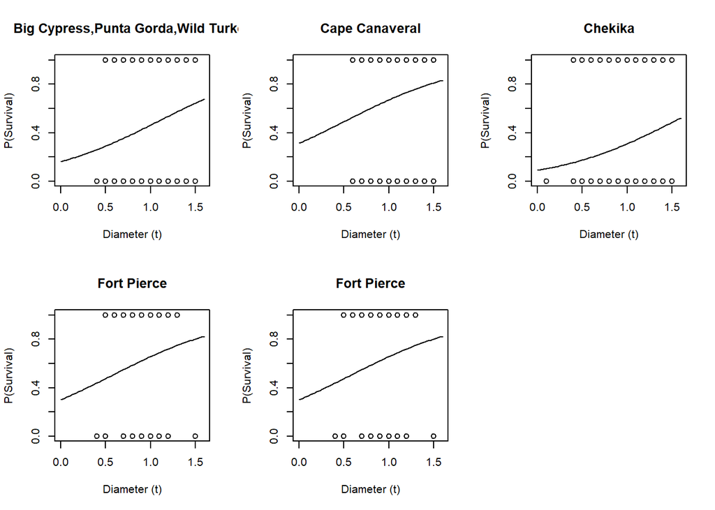

```r
  par(mfrow=c(2, 3))

plot(x1seq_seedlings, invlogit(s3$coeff[1] + s3$coeff[2]*x1seq_seedlings), type='l', ylim=c(0,1) , xlab = "Diameter (t)", ylab="P(Survival)", main = "Big Cypress,Punta Gorda,Wild Turkey")
points(seedlings[seedlings$Site=="Big Cypress" | seedlings$Site == "Punta Gorda" | seedlings$Site == "Wild Turkey", ]$Diameter_t, seedlings[seedlings$Site=="Big Cypress" | seedlings$Site == "Punta Gorda" | seedlings$Site == "Wild Turkey", ]$Surv_tplus1)

plot(x1seq_seedlings, invlogit(s3$coeff[1] + s3$coeff[2]*x1seq_seedlings + s3$coeff[3]), type='l', ylim=c(0,1) , xlab = "Diameter (t)", ylab="P(Survival)", main = "Cape Canaveral")
points(seedlings[seedlings$Site=="Cape Canaveral", ]$Diameter_t, seedlings[seedlings$Site=="Cape Canaveral", ]$Surv_tplus1)

plot(x1seq_seedlings, invlogit(s3$coeff[1] + s3$coeff[2]*x1seq_seedlings + s3$coeff[4]), type='l', ylim=c(0,1) , xlab = "Diameter (t)", ylab="P(Survival)", main = "Chekika")
points(seedlings[seedlings$Site=="Chekika", ]$Diameter_t, seedlings[seedlings$Site=="Chekika", ]$Surv_tplus1)

plot(x1seq_seedlings, invlogit(s3$coeff[1] + s3$coeff[2]*x1seq_seedlings + s3$coeff[5]), type='l', ylim=c(0,1) , xlab = "Diameter (t)", ylab="P(Survival)", main = "Fort Pierce")
points(seedlings[seedlings$Site=="Fort Pierce", ]$Diameter_t, seedlings[seedlings$Site=="Fort Pierce", ]$Surv_tplus1)

plot(x1seq_seedlings, invlogit(s3$coeff[1] + s3$coeff[2]*x1seq_seedlings + s3$coeff[5]), type='l', ylim=c(0,1) , xlab = "Diameter (t)", ylab="P(Survival)", main = "Fort Pierce")
points(seedlings[seedlings$Site=="Fort Pierce", ]$Diameter_t, seedlings[seedlings$Site=="Fort Pierce", ]$Surv_tplus1)
```

### –s4: logit(S1) = b0 + b1(diameter) + epsilon(year{2010, 2011, 2012, 2013}

```r
seedlings2 <- subset(seedlings, seedlings$Year > 2009 & seedlings$Year <2014)
seedlings2$Year <- as.factor(seedlings2$Year)
s4 <- glm(seedlings2$Surv_tplus1 ~ seedlings2$Diameter_t + seedlings2$Year, family = binomial)
summary(s4)
```

```
##
## Call:
## glm(formula = seedlings2$Surv_tplus1 ~ seedlings2$Diameter_t +
##     seedlings2$Year, family = binomial)
##
## Deviance Residuals:
##     Min       1Q   Median       3Q      Max
## -1.9271  -0.8425  -0.5799   1.0266   2.2450
##
## Coefficients:
##                       Estimate Std. Error z value Pr(>|z|)
## (Intercept)            -2.2701     0.3664  -6.196 5.78e-10 ***
## seedlings2$Diameter_t   2.6381     0.3501   7.534 4.91e-14 ***
## seedlings2$Year2011    -1.3286     0.3311  -4.013 6.01e-05 ***
## seedlings2$Year2012    -1.2213     0.2013  -6.066 1.31e-09 ***
## seedlings2$Year2013    -0.8547     0.2441  -3.501 0.000464 ***
## ---
## Signif. codes:  0 '***' 0.001 '**' 0.01 '*' 0.05 '.' 0.1 ' ' 1
##
## (Dispersion parameter for binomial family taken to be 1)
##
##     Null deviance: 975.17  on 759  degrees of freedom
## Residual deviance: 855.14  on 755  degrees of freedom
##   (10 observations deleted due to missingness)
## AIC: 865.14
##
## Number of Fisher Scoring iterations: 3
```

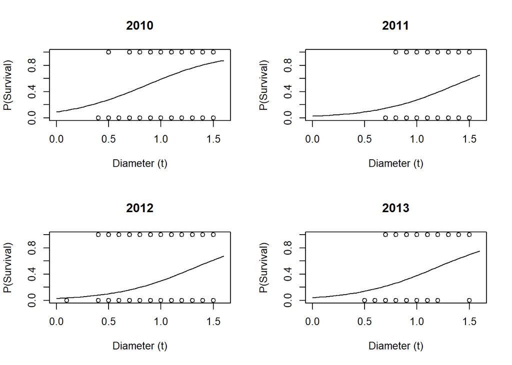

```r
par(mfrow=c(2,2))
plot(x1seq_seedlings, invlogit(s4$coeff[1] + s4$coeff[2]*x1seq_seedlings ), type='l', ylim=c(0,1) , xlab = "Diameter (t)", ylab="P(Survival)", main = "2010")
points(seedlings2[seedlings2$Year=="2010", ]$Diameter_t, seedlings2[seedlings2$Year=="2010", ]$Surv_tplus1)
plot(x1seq_seedlings, invlogit(s4$coeff[1] + s4$coeff[2]*x1seq_seedlings + s4$coeff[3] ), type='l', ylim=c(0,1) , xlab = "Diameter (t)", ylab="P(Survival)", main = "2011")
points(seedlings2[seedlings2$Year=="2011", ]$Diameter_t, seedlings2[seedlings2$Year=="2011", ]$Surv_tplus1)
plot(x1seq_seedlings, invlogit(s4$coeff[1] + s4$coeff[2]*x1seq_seedlings + s4$coeff[4] ), type='l', ylim=c(0,1) , xlab = "Diameter (t)", ylab="P(Survival)", main = "2012")
points(seedlings2[seedlings2$Year=="2012", ]$Diameter_t, seedlings2[seedlings2$Year=="2012", ]$Surv_tplus1)

plot(x1seq_seedlings, invlogit(s4$coeff[1] + s4$coeff[2]*x1seq_seedlings + s4$coeff[5] ), type='l', ylim=c(0,1) , xlab = "Diameter (t)", ylab="P(Survival)", main = "2013")
points(seedlings2[seedlings2$Year=="2013", ]$Diameter_t, seedlings2[seedlings2$Year=="2013", ]$Surv_tplus1)
```

### –s5: logit(S1) = b0 + b1(height)

```r
  s5 <- glm(seedlings$Surv_tplus1 ~ seedlings$Height_t, family = binomial)
  summary(s5)
```

```
##
## Call:
## glm(formula = seedlings$Surv_tplus1 ~ seedlings$Height_t, family = binomial)
##
## Deviance Residuals:
##     Min       1Q   Median       3Q      Max
## -1.5141  -0.9658  -0.7677   1.2433   1.8983
##
## Coefficients:
##                    Estimate Std. Error z value Pr(>|z|)
## (Intercept)        -1.98831    0.22657  -8.776  < 2e-16 ***
## seedlings$Height_t  0.18347    0.02459   7.460 8.65e-14 ***
## ---
## Signif. codes:  0 '***' 0.001 '**' 0.01 '*' 0.05 '.' 0.1 ' ' 1
##
## (Dispersion parameter for binomial family taken to be 1)
##
##     Null deviance: 1205.5  on 894  degrees of freedom
## Residual deviance: 1145.7  on 893  degrees of freedom
##   (64 observations deleted due to missingness)
## AIC: 1149.7
##
## Number of Fisher Scoring iterations: 4
```

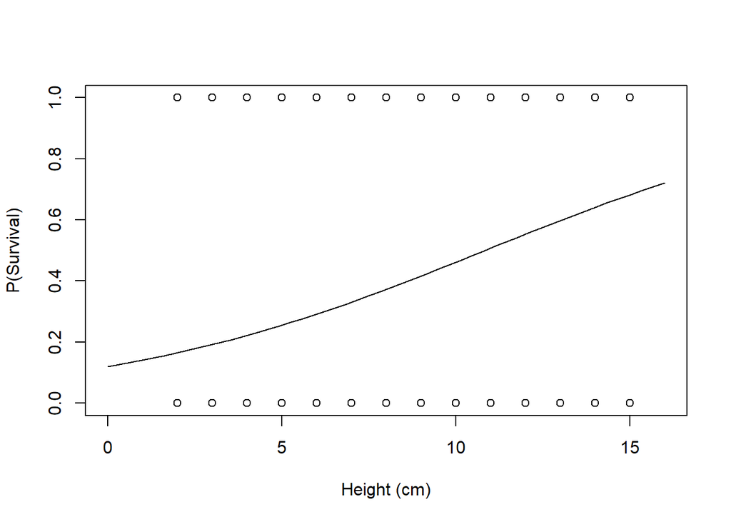

```r
plot(x2seq_seedlings, invlogit(s5$coeff[1] + s5$coeff[2]*x2seq_seedlings), type='l', ylim=c(0,1) , xlab = "Height (cm)", ylab="P(Survival)")
points(seedlings$Height_t, seedlings$Surv_tplus1)
```

### –s6: logit(S1) = b0 + b1(height) + epsilon(biotype{E,H,W}) Eastern and Western are not significantly different.

```r
 s6 <- glm(seedlings$Surv_tplus1 ~ seedlings$Height_t + seedlings$Genetic_type, family = binomial)
summary(s6)
```

```
##
## Call:
## glm(formula = seedlings$Surv_tplus1 ~ seedlings$Height_t + seedlings$Genetic_type,
##     family = binomial)
##
## Deviance Residuals:
##     Min       1Q   Median       3Q      Max
## -1.6881  -0.9950  -0.6805   1.1478   1.9655
##
## Coefficients:
##                               Estimate Std. Error z value Pr(>|z|)
## (Intercept)                   -2.24473    0.24040  -9.338  < 2e-16 ***
## seedlings$Height_t             0.17992    0.02514   7.156 8.33e-13 ***
## seedlings$Genetic_typehybrid   0.69555    0.15302   4.546 5.48e-06 ***
## seedlings$Genetic_typewestern  0.10987    0.23022   0.477    0.633
## ---
## Signif. codes:  0 '***' 0.001 '**' 0.01 '*' 0.05 '.' 0.1 ' ' 1
##
## (Dispersion parameter for binomial family taken to be 1)
##
##     Null deviance: 1205.5  on 894  degrees of freedom
## Residual deviance: 1124.0  on 891  degrees of freedom
##   (64 observations deleted due to missingness)
## AIC: 1132
##
## Number of Fisher Scoring iterations: 4
```

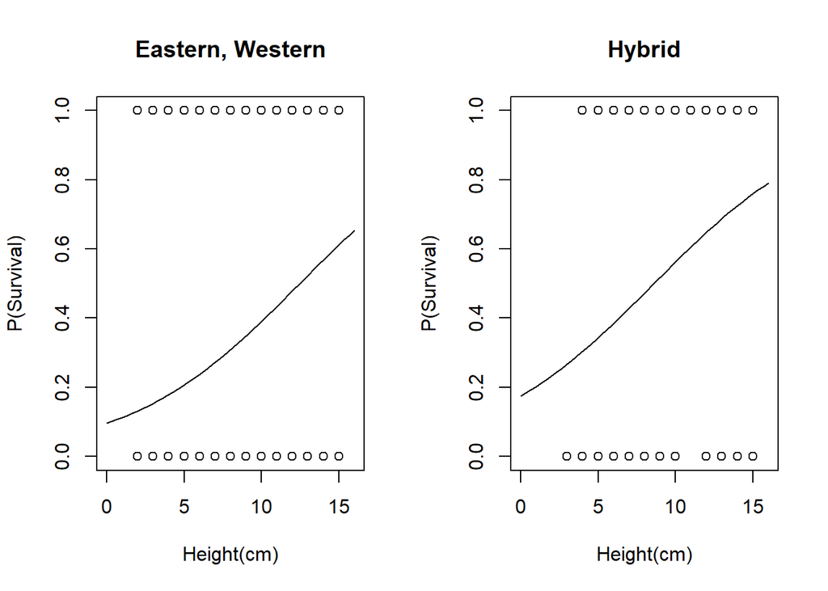

```r
par(mfrow=c(1, 2))

plot(x2seq_seedlings, invlogit(s6$coeff[1] + s6$coeff[2]*x2seq_seedlings), type='l', ylim=c(0,1) , xlab = "Height(cm)", ylab="P(Survival)", main = "Eastern, Western")
points(seedlings[seedlings$Genetic_type=="eastern" | seedlings$Genetic_type == "western", ]$Height_t, seedlings[seedlings$Genetic_type=="eastern" | seedlings$Genetic_type == "western", ]$Surv_tplus1)

plot(x2seq_seedlings, invlogit(s6$coeff[1] + s6$coeff[2]*x2seq_seedlings + s6$coeff[3]), type='l', ylim=c(0,1) , xlab = "Height(cm)", ylab="P(Survival)", main = "Hybrid")
points(seedlings[seedlings$Genetic_type=="hybrid", ]$Height_t, seedlings[seedlings$Genetic_type=="hybrid", ]$Surv_tplus1)
```

### –s7: logit(S1) = b0 + b1(height) + epsilon(site{BC, CC, C, FP, PG, WT}) Big Cypress, Chekika, Punta Gorda and Wild Turkey are not significantly different

```r
  s7 <- glm(seedlings$Surv_tplus1 ~ seedlings$Height_t + seedlings$Site, family = binomial)
  summary(s7)
```

```
##
## Call:
## glm(formula = seedlings$Surv_tplus1 ~ seedlings$Height_t + seedlings$Site,
##     family = binomial)
##
## Deviance Residuals:
##     Min       1Q   Median       3Q      Max
## -2.0745  -0.8430  -0.6575   1.0759   2.0734
##
## Coefficients:
##                              Estimate Std. Error z value Pr(>|z|)
## (Intercept)                  -2.22581    0.28718  -7.751 9.15e-15 ***
## seedlings$Height_t            0.18995    0.02633   7.215 5.41e-13 ***
## seedlings$SiteCape Canaveral  1.40481    0.24139   5.820 5.89e-09 ***
## seedlings$SiteChekika        -0.33563    0.19444  -1.726  0.08433 .
## seedlings$SiteFort Pierce     0.93892    0.29438   3.189  0.00143 **
## seedlings$SitePunta Gorda     0.20708    0.33826   0.612  0.54041
## seedlings$SiteWild Turkey    -0.17968    0.31882  -0.564  0.57304
## ---
## Signif. codes:  0 '***' 0.001 '**' 0.01 '*' 0.05 '.' 0.1 ' ' 1
##
## (Dispersion parameter for binomial family taken to be 1)
##
##     Null deviance: 1205.5  on 894  degrees of freedom
## Residual deviance: 1065.3  on 888  degrees of freedom
##   (64 observations deleted due to missingness)
## AIC: 1079.3
##
## Number of Fisher Scoring iterations: 4
```

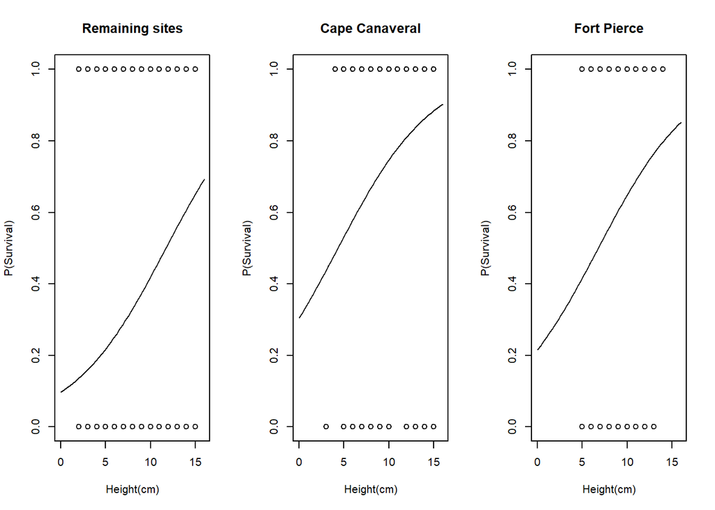

```r
  par(mfrow=c(1,3))
  plot(x2seq_seedlings, invlogit(s7$coeff[1] + s7$coeff[2]*x2seq_seedlings), type='l', ylim=c(0,1) , xlab = "Height(cm)", ylab="P(Survival)", main = "Remaining sites")
points(seedlings[seedlings$Site!="Fort Pierce" & seedlings$Site!= "Cape Canaveral", ]$Height_t, seedlings[seedlings$Site!="Fort Pierce" & seedlings$Site != "Cape Canaveral", ]$Surv_tplus1)

 plot(x2seq_seedlings, invlogit(s7$coeff[1] + s7$coeff[2]*x2seq_seedlings + s7$coeff[3]), type='l', ylim=c(0,1) , xlab = "Height(cm)", ylab="P(Survival)", main = "Cape Canaveral")
points(seedlings[seedlings$Site== "Cape Canaveral", ]$Height_t, seedlings[seedlings$Site=="Cape Canaveral", ]$Surv_tplus1)

 plot(x2seq_seedlings, invlogit(s7$coeff[1] + s7$coeff[2]*x2seq_seedlings + s7$coeff[5]), type='l', ylim=c(0,1) , xlab = "Height(cm)", ylab="P(Survival)", main = "Fort Pierce")
points(seedlings[seedlings$Site== "Fort Pierce", ]$Height_t, seedlings[seedlings$Site=="Fort Pierce", ]$Surv_tplus1)
```

### –s8: logit(S1) = b0 + b1(height) + epsilon(year{2010, 2011, 2012, 2013}

```r
s8 <- glm(seedlings2$Surv_tplus1 ~ seedlings2$Height_t + seedlings2$Year, family = binomial)
summary(s8)
```

```
##
## Call:
## glm(formula = seedlings2$Surv_tplus1 ~ seedlings2$Height_t +
##     seedlings2$Year, family = binomial)
##
## Deviance Residuals:
##     Min       1Q   Median       3Q      Max
## -1.6236  -0.8327  -0.6846   1.0879   1.9582
##
## Coefficients:
##                     Estimate Std. Error z value Pr(>|z|)
## (Intercept)         -1.12710    0.31658  -3.560  0.00037 ***
## seedlings2$Height_t  0.14225    0.02872   4.953 7.31e-07 ***
## seedlings2$Year2011 -0.65015    0.31262  -2.080  0.03756 *
## seedlings2$Year2012 -1.05793    0.20488  -5.164 2.42e-07 ***
## seedlings2$Year2013 -1.10537    0.23370  -4.730 2.25e-06 ***
## ---
## Signif. codes:  0 '***' 0.001 '**' 0.01 '*' 0.05 '.' 0.1 ' ' 1
##
## (Dispersion parameter for binomial family taken to be 1)
##
##     Null deviance: 975.17  on 759  degrees of freedom
## Residual deviance: 892.24  on 755  degrees of freedom
##   (10 observations deleted due to missingness)
## AIC: 902.24
##
## Number of Fisher Scoring iterations: 4
```

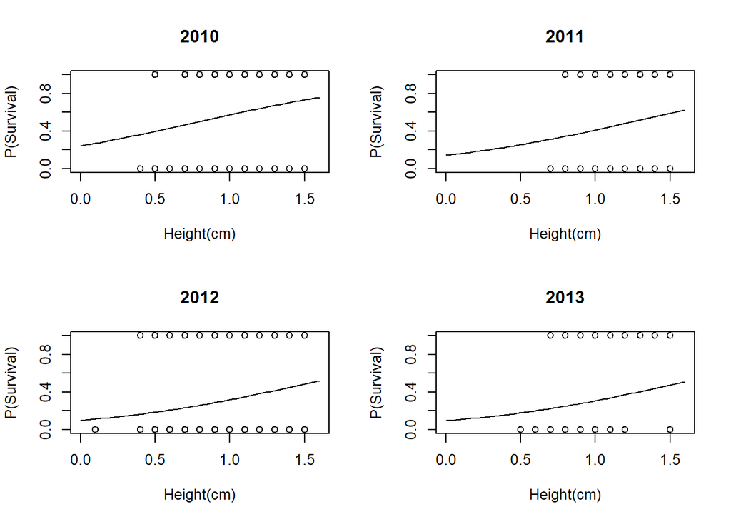

```r
par(mfrow=c(2,2))
plot(x1seq_seedlings, invlogit(s8$coeff[1] + s8$coeff[2]*x2seq_seedlings ), type='l', ylim=c(0,1) , xlab = "Height(cm)", ylab="P(Survival)", main = "2010")
points(seedlings2[seedlings2$Year=="2010", ]$Diameter_t, seedlings2[seedlings2$Year=="2010", ]$Surv_tplus1)

plot(x1seq_seedlings, invlogit(s8$coeff[1] + s8$coeff[2]*x2seq_seedlings + s8$coeff[3] ), type='l', ylim=c(0,1) , xlab = "Height(cm)", ylab="P(Survival)", main = "2011")
points(seedlings2[seedlings2$Year=="2011", ]$Diameter_t, seedlings2[seedlings2$Year=="2011", ]$Surv_tplus1)

plot(x1seq_seedlings, invlogit(s8$coeff[1] + s8$coeff[2]*x2seq_seedlings +s8$coeff[4] ), type='l', ylim=c(0,1) , xlab = "Height(cm)", ylab="P(Survival)", main = "2012")
points(seedlings2[seedlings2$Year=="2012", ]$Diameter_t, seedlings2[seedlings2$Year=="2012", ]$Surv_tplus1)

plot(x1seq_seedlings, invlogit(s8$coeff[1] + s8$coeff[2]*x2seq_seedlings +s8$coeff[5] ), type='l', ylim=c(0,1) , xlab = "Height(cm)", ylab="P(Survival)", main = "2013")
points(seedlings2[seedlings2$Year=="2013", ]$Diameter_t, seedlings2[seedlings2$Year=="2013", ]$Surv_tplus1)
```

### - Diameter + Height models ### –s9: logit(S1) = b0 + b1(diameter) + b2(height)

```r
  s9 <- glm(seedlings$Surv_tplus1 ~ seedlings$Diameter_t + seedlings$Height_t, family =
                binomial)
  summary(s9)
```

```
##
## Call:
## glm(formula = seedlings$Surv_tplus1 ~ seedlings$Diameter_t +
##     seedlings$Height_t, family = binomial)
##
## Deviance Residuals:
##     Min       1Q   Median       3Q      Max
## -1.7261  -0.9675  -0.7608   1.2097   1.8590
##
## Coefficients:
##                      Estimate Std. Error z value Pr(>|z|)
## (Intercept)          -2.69517    0.29497  -9.137  < 2e-16 ***
## seedlings$Diameter_t  1.15081    0.29283   3.930 8.49e-05 ***
## seedlings$Height_t    0.14688    0.02611   5.625 1.86e-08 ***
## ---
## Signif. codes:  0 '***' 0.001 '**' 0.01 '*' 0.05 '.' 0.1 ' ' 1
##
## (Dispersion parameter for binomial family taken to be 1)
##
##     Null deviance: 1205.5  on 894  degrees of freedom
## Residual deviance: 1130.0  on 892  degrees of freedom
##   (64 observations deleted due to missingness)
## AIC: 1136
##
## Number of Fisher Scoring iterations: 4
```

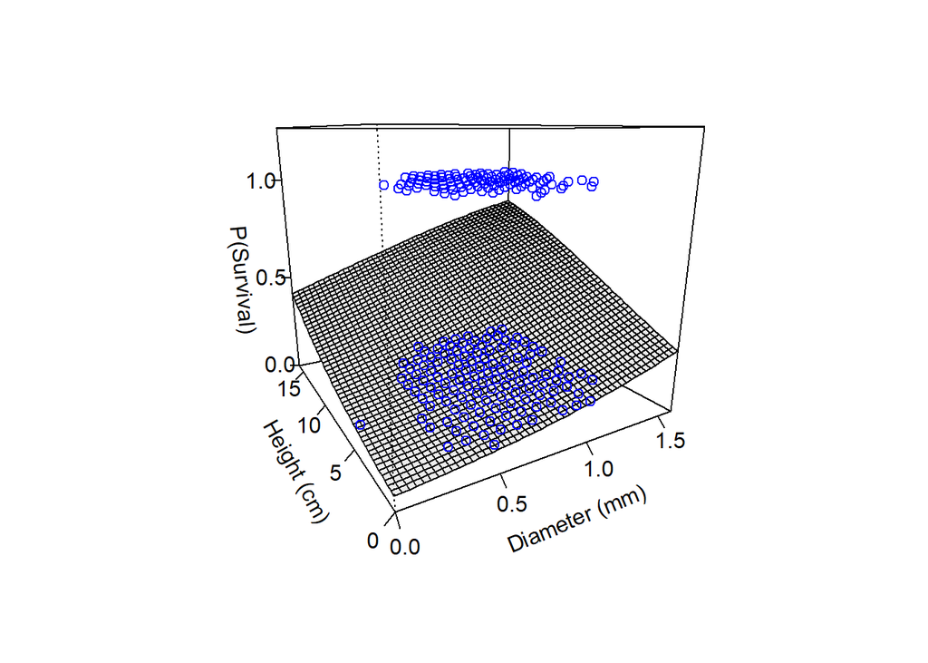

```r
 b0<- s9$coeff[1]
 b1<- s9$coeff[2]
 b2<- s9$coeff[3]


z1<-outer(x1seq_seedlings, x2seq_seedlings, function(a,b) (invlogit(b0 + b1*a + b2*b)))

pmat<-persp(x1seq_seedlings, x2seq_seedlings, z1, ticktype="detailed",
      theta=-30, zlim=c(0, 1.25), zlab="\n P(Survival)",
      shade=0.1, nticks=4, xlab="\n Diameter (mm)",
      ylab="\n Height (cm)",  lwd=1, xaxs="i",
      main="", cex.main=1)

# from 3D to 2D coordinates
mypoints <- trans3d(seedlings$Diameter_t, seedlings$Height_t, seedlings$Surv_tplus1, pmat=pmat)
# plot in 2D space with pointsize related to distance
points(mypoints, col=4)
```

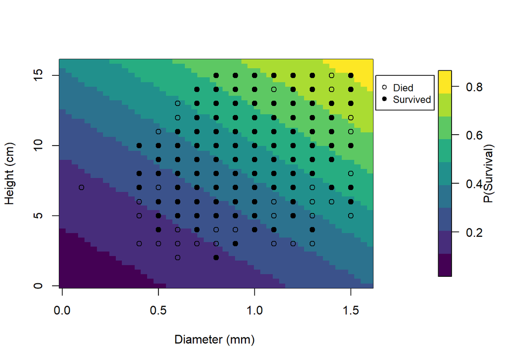

```r
par(mar=c(5.1,4.1,4.1,6))
image.plot(x1seq_seedlings, x2seq_seedlings, z1, xlab = "Diameter (mm) ", ylab="Height (cm)", col=my.palette, legend.lab = "P(Survival)")
points(seedlings$Diameter_t[seedlings$Surv_tplus1==1], seedlings$Height_t[seedlings$Surv_tplus1==1], pch=19)
points(seedlings$Diameter_t[seedlings$Surv_tplus1==0], seedlings$Height_t[seedlings$Surv_tplus1==0], pch=1)
legend(1.63, 15, pch=c(1,19), cex = 0.8, text.width=0.19, c("Died", "Survived"), xpd=T)
```

### –s10: logit(S1) = b0 + b1(diameter) + b2(height) + epsilon(biotype{E,H,W}) Eastern and Western are not different

```r
 s10 <- glm(seedlings$Surv_tplus1~ seedlings$Diameter_t + seedlings$Height_t +seedlings$Genetic_type,         family=binomial)
summary(s10)
```

```
##
## Call:
## glm(formula = seedlings$Surv_tplus1 ~ seedlings$Diameter_t +
##     seedlings$Height_t + seedlings$Genetic_type, family = binomial)
##
## Deviance Residuals:
##     Min       1Q   Median       3Q      Max
## -1.7941  -0.9072  -0.7050   1.1467   1.9812
##
## Coefficients:
##                               Estimate Std. Error z value Pr(>|z|)
## (Intercept)                   -2.98324    0.30633  -9.739  < 2e-16 ***
## seedlings$Diameter_t           1.21279    0.29710   4.082 4.46e-05 ***
## seedlings$Height_t             0.14144    0.02667   5.303 1.14e-07 ***
## seedlings$Genetic_typehybrid   0.71158    0.15497   4.592 4.39e-06 ***
## seedlings$Genetic_typewestern  0.02646    0.23268   0.114    0.909
## ---
## Signif. codes:  0 '***' 0.001 '**' 0.01 '*' 0.05 '.' 0.1 ' ' 1
##
## (Dispersion parameter for binomial family taken to be 1)
##
##     Null deviance: 1205.5  on 894  degrees of freedom
## Residual deviance: 1107.0  on 890  degrees of freedom
##   (64 observations deleted due to missingness)
## AIC: 1117
##
## Number of Fisher Scoring iterations: 4
```

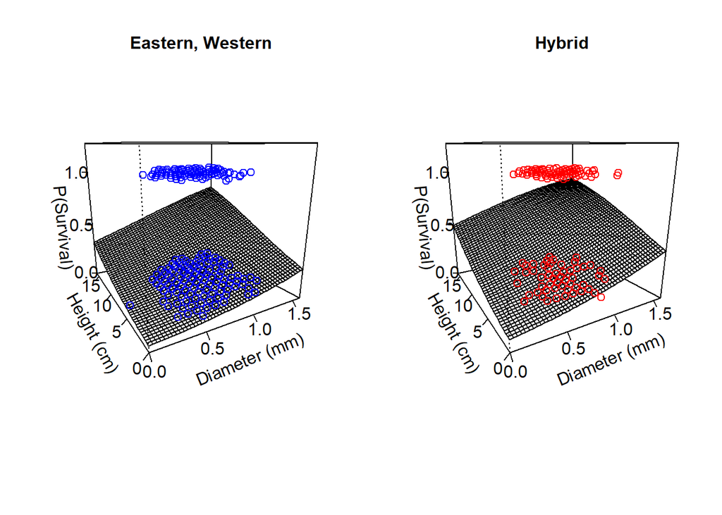

```r
par(mfrow=c(1,2))

#E
b0 <- s10$coeff[1]
b1 <- s10$coeff[2]
b2 <- s10$coeff[3]
z1<-outer(x1seq_seedlings, x2seq_seedlings, function(a,b) (invlogit(b0 + b1*a + b2*b)))

pmat<-persp(x1seq_seedlings, x2seq_seedlings, z1, ticktype="detailed",
      theta=-30, zlim=c(0, 1.25), zlab="\n P(Survival)",
      shade=0.1, nticks=4, xlab="\n Diameter (mm)",
      ylab="\n Height (cm)",  lwd=1, xaxs="i",
      main="Eastern, Western", cex.main=1)

# from 3D to 2D coordinates
mypoints <- trans3d(seedlings$Diameter_t[seedlings$Genetic_type=="eastern" | seedlings$Genetic_type == "western"], seedlings$Height_t[seedlings$Genetic_type=="eastern" | seedlings$Genetic_type == "western"], seedlings$Surv_tplus1[seedlings$Genetic_type=="eastern" | seedlings$Genetic_type == "western"], pmat=pmat)
# plot in 2D space with pointsize related to distance
points(mypoints, col=4)
#H
b0 <- s10$coeff[1] + s10$coeff[4]
b1 <- s10$coeff[2]
b2 <- s10$coeff[3]


z1<-outer(x1seq_seedlings, x2seq_seedlings, function(a,b) (invlogit(b0 + b1*a + b2*b)))

pmat<-persp(x1seq_seedlings, x2seq_seedlings, z1, ticktype="detailed",
      theta=-30, zlim=c(0, 1.25), zlab="\n P(Survival)",
      shade=0.1, nticks=4, xlab="\n Diameter (mm)",
      ylab="\n Height (cm)",  lwd=1, xaxs="i",
      main="Hybrid", cex.main=1)

# from 3D to 2D coordinates
mypoints <- trans3d(seedlings$Diameter_t[seedlings$Genetic_type=="hybrid"], seedlings$Height_t[seedlings$Genetic_type=="hybrid"], seedlings$Surv_tplus1[seedlings$Genetic_type=="hybrid"], pmat=pmat)
# plot in 2D space with pointsize related to distance
points(mypoints, col="red")
```

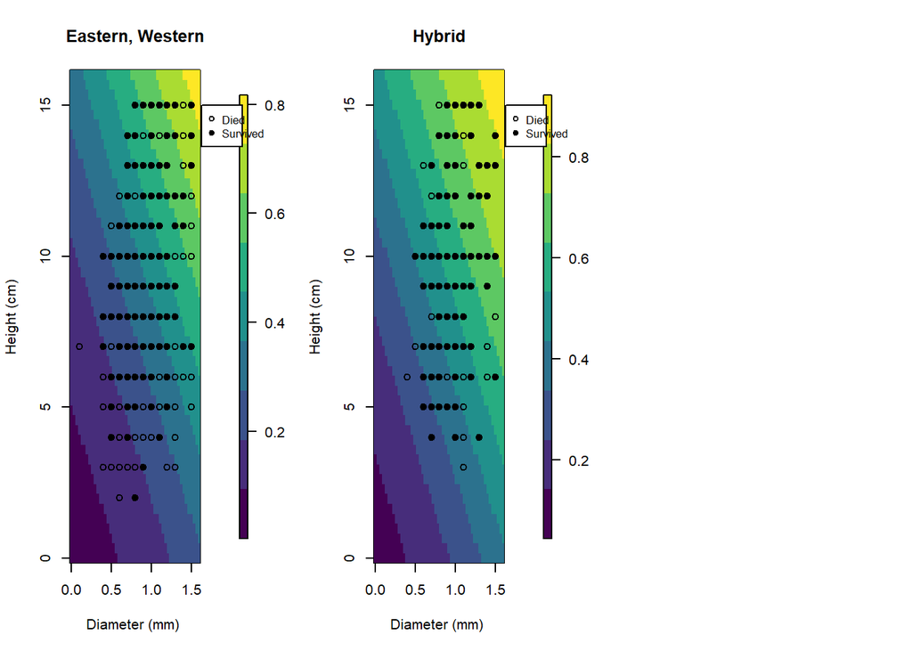

```r
par(mfrow=c(1,2))
#EASTERN
b0 <- s10$coeff[1]
b1 <- s10$coeff[2]
b2 <- s10$coeff[3]

z1<-outer(x1seq_seedlings, x2seq_seedlings, function(a,b) (invlogit(b0 + b1*a + b2*b)))
par(mfrow=c(1,3))
par(mar=c(5.1,4.1,4.1,6))
image.plot(x1seq_seedlings, x2seq_seedlings, z1, xlab = "Diameter (mm) ", ylab="Height (cm)", main="Eastern, Western",col=my.palette)
points(seedlings$Diameter_t[seedlings$Surv_tplus1==1 & (seedlings$Genetic_type=="eastern" | seedlings$Genetic_type == "western")], seedlings$Height_t[seedlings$Surv_tplus1==1& (seedlings$Genetic_type=="eastern" | seedlings$Genetic_type == "western")], pch=19)
points(seedlings$Diameter_t[seedlings$Surv_tplus1==0 & (seedlings$Genetic_type=="eastern" | seedlings$Genetic_type == "western")], seedlings$Height_t[seedlings$Surv_tplus1==0&(seedlings$Genetic_type=="eastern" | seedlings$Genetic_type == "western")], pch=1)
legend(1.63, 15, pch=c(1,19), cex = 0.8, text.width=0.19, c("Died", "Survived"), xpd=T)


#HYBRID
b0 <- s10$coeff[1] + s10$coeff[4]
b1 <- s10$coeff[2]
b2 <- s10$coeff[3]
z1<-outer(x1seq_seedlings, x2seq_seedlings, function(a,b) (invlogit(b0 + b1*a + b2*b)))
image.plot(x1seq_seedlings, x2seq_seedlings, z1, xlab = "Diameter (mm) ", ylab="Height (cm)", main="Hybrid", col=my.palette)
points(seedlings$Diameter_t[seedlings$Surv_tplus1==1 & seedlings$Genetic_type=="hybrid"], seedlings$Height_t[seedlings$Surv_tplus1==1& seedlings$Genetic_type=="hybrid"], pch=19)
points(seedlings$Diameter_t[seedlings$Surv_tplus1==0 & seedlings$Genetic_type=="hybrid"], seedlings$Height_t[seedlings$Surv_tplus1==0&seedlings$Genetic_type=="hybrid"], pch=1)
legend(1.63, 15, pch=c(1,19), cex = 0.8, text.width=0.19, c("Died", "Survived"), xpd=T)
```

### –s11: logit(S1) = logit(S1) = b0 + b1(diameter) + b2(height) + epsilon(site{BC, CC, C, FP, PG,WT})

Big Cypress, Punta Gorda and Wild Turkey are not different

```r
s11 <- glm(seedlings$Surv_tplus1 ~ seedlings$Diameter_t + seedlings$Height_t +
              seedlings$Site, family = binomial)
summary(s11)
```

```
##
## Call:
## glm(formula = seedlings$Surv_tplus1 ~ seedlings$Diameter_t +
##     seedlings$Height_t + seedlings$Site, family = binomial)
##
## Deviance Residuals:
##     Min       1Q   Median       3Q      Max
## -2.0535  -0.8283  -0.6536   1.0788   2.0434
##
## Coefficients:
##                              Estimate Std. Error z value Pr(>|z|)
## (Intercept)                  -2.54026    0.32467  -7.824 5.11e-15 ***
## seedlings$Diameter_t          0.71326    0.32712   2.180  0.02923 *
## seedlings$Height_t            0.16387    0.02869   5.712 1.12e-08 ***
## seedlings$SiteCape Canaveral  1.20530    0.25818   4.668 3.03e-06 ***
## seedlings$SiteChekika        -0.42719    0.20037  -2.132  0.03300 *
## seedlings$SiteFort Pierce     0.87726    0.29690   2.955  0.00313 **
## seedlings$SitePunta Gorda     0.02454    0.35144   0.070  0.94434
## seedlings$SiteWild Turkey    -0.27056    0.32132  -0.842  0.39978
## ---
## Signif. codes:  0 '***' 0.001 '**' 0.01 '*' 0.05 '.' 0.1 ' ' 1
##
## (Dispersion parameter for binomial family taken to be 1)
##
##     Null deviance: 1205.5  on 894  degrees of freedom
## Residual deviance: 1060.5  on 887  degrees of freedom
##   (64 observations deleted due to missingness)
## AIC: 1076.5
##
## Number of Fisher Scoring iterations: 4
```

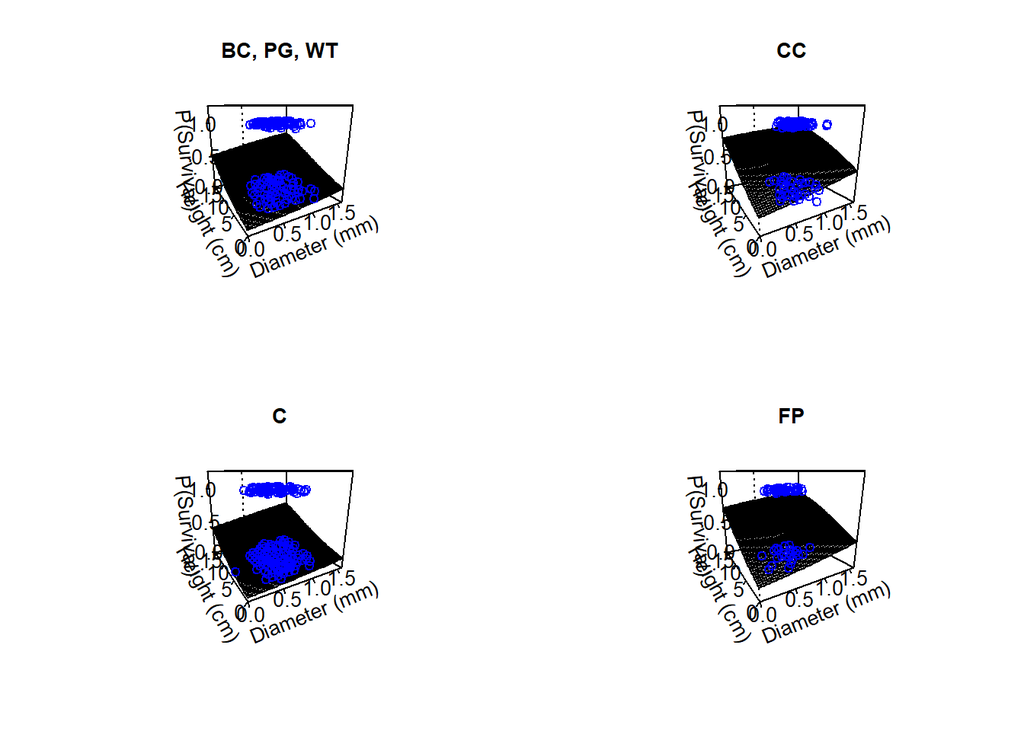

```r
par(mfrow=c(2,2))
  #Big Cypress, Punta Gorda and Wild Turkey
b0 <- s11$coeff[1]
b1 <- s11$coeff[2]
b2 <- s11$coeff[3]
z1<-outer(x1seq_seedlings, x2seq_seedlings, function(a,b) (invlogit(b0 + b1*a + b2*b)))

pmat<-persp(x1seq_seedlings, x2seq_seedlings, z1, ticktype="detailed",
      theta=-30, zlim=c(0, 1.25), zlab="\n P(Survival)",
      shade=0.1, nticks=4, xlab="\n Diameter (mm)",
      ylab="\n Height (cm)",  lwd=1, xaxs="i",
      main="BC, PG, WT", cex.main=1)

# from 3D to 2D coordinates
mypoints <- trans3d(seedlings$Diameter_t[seedlings$Site=="Big Cypress" | seedlings$Site == "Punta Gorda" | seedlings$Site == "Wild Turkey"], seedlings$Height_t[seedlings$Site=="Big Cypress" | seedlings$Site == "Punta Gorda" | seedlings$Site == "Wild Turkey"], seedlings$Surv_tplus1[seedlings$Site=="Big Cypress" | seedlings$Site == "Punta Gorda" | seedlings$Site == "Wild Turkey"], pmat=pmat)
# plot in 2D space with pointsize related to distance
points(mypoints, col=4)

#Cape Canaveral
b0 <- s11$coeff[1] + s11$coeff[4]
b1 <- s11$coeff[2]
b2 <- s11$coeff[3]
z1<-outer(x1seq_seedlings, x2seq_seedlings, function(a,b) (invlogit(b0 + b1*a + b2*b)))

pmat<-persp(x1seq_seedlings, x2seq_seedlings, z1, ticktype="detailed",
      theta=-30, zlim=c(0, 1.25), zlab="\n P(Survival)",
      shade=0.1, nticks=4, xlab="\n Diameter (mm)",
      ylab="\n Height (cm)",  lwd=1, xaxs="i",
      main="CC", cex.main=1)

# from 3D to 2D coordinates
mypoints <- trans3d(seedlings$Diameter_t[seedlings$Site=="Cape Canaveral"], seedlings$Height_t[seedlings$Site=="Cape Canaveral"], seedlings$Surv_tplus1[seedlings$Site=="Cape Canaveral"], pmat=pmat)
# plot in 2D space with pointsize related to distance
points(mypoints, col=4)


#Chekika
b0 <- s11$coeff[1] + s11$coeff[5]
b1 <- s11$coeff[2]
b2 <- s11$coeff[3]
z1<-outer(x1seq_seedlings, x2seq_seedlings, function(a,b) (invlogit(b0 + b1*a + b2*b)))

pmat<-persp(x1seq_seedlings, x2seq_seedlings, z1, ticktype="detailed",
      theta=-30, zlim=c(0, 1.25), zlab="\n P(Survival)",
      shade=0.1, nticks=4, xlab="\n Diameter (mm)",
      ylab="\n Height (cm)",  lwd=1, xaxs="i",
      main="C", cex.main=1)

# from 3D to 2D coordinates
mypoints <- trans3d(seedlings$Diameter_t[seedlings$Site=="Chekika"], seedlings$Height_t[seedlings$Site=="Chekika"], seedlings$Surv_tplus1[seedlings$Site=="Chekika"], pmat=pmat)
# plot in 2D space with pointsize related to distance
points(mypoints, col=4)

#Fort Pierce
b0 <- s11$coeff[1] + s11$coeff[6]
b1 <- s11$coeff[2]
b2 <- s11$coeff[3]
z1<-outer(x1seq_seedlings, x2seq_seedlings, function(a,b) (invlogit(b0 + b1*a + b2*b)))

pmat<-persp(x1seq_seedlings, x2seq_seedlings, z1, ticktype="detailed",
      theta=-30, zlim=c(0, 1.25), zlab="\n P(Survival)",
      shade=0.1, nticks=4, xlab="\n Diameter (mm)",
      ylab="\n Height (cm)",  lwd=1, xaxs="i",
      main="FP", cex.main=1)

# from 3D to 2D coordinates
mypoints <- trans3d(seedlings$Diameter_t[seedlings$Site=="Fort Pierce"], seedlings$Height_t[seedlings$Site=="Fort Pierce"], seedlings$Surv_tplus1[seedlings$Site=="Fort Pierce"], pmat=pmat)
# plot in 2D space with pointsize related to distance
points(mypoints, col=4)
```